# Multivariate Analysis Lecture 3: Random Vectors and Random Samples

Zhaoxia Yu

Professor, Department of Statistics

2026-05-31

# Outline

0. Introduction
1. Random variables and random samples
2. Random vectors and random samples
3. Linear combinations of random vectors

# Introduction

## Random Matrix

$$\mathbf X =\begin{pmatrix}
X_{11} & X_{12} & \cdots & X_{1j} & \cdots & X_{1p}\\
X_{21} & X_{22} & \cdots & X_{2j} & \cdots & X_{2p}\\
\cdots & \cdots & \cdots & \cdots & \cdots & \cdots\\
X_{i1} & X_{i2} & \cdots & \color{red}{X_{ij}} & \cdots & X_{ip}\\
\cdots & \cdots & \cdots & \cdots & \cdots & \cdots\\
X_{n1} & X_{n2} & \cdots & X_{nj} & \cdots & X_{np}\\
\end{pmatrix}$$

## Definitions and Notations

- $X_{ij}$, e.g. $X_{12}$, is a random variable.
- random vectors
  - $(X_{i1}, \cdots, X_{ip})$ is a random vector (row vector).
  - $(X_{1j}, \cdots, X_{nj})^T$ is a random vector (column vector).
- $\mathbf{X}$ is a $n\times p$ random matrix.

## Assumptions

- A typical scenario for the $n\times p$ matrix $\mathbf X$ is that we have $n$ independent and identically distributed (iid) rows
- Each row follows a p-dimensional multivariate distribution (say, multivariate normal). The variables in each row may be correlated and we typically estimate the covariance/correlation matrix to capture the correlation.
- Each column follows a multivariate distribution and the random variables of each columns are independent and identically distributed (iid).

## A Univariate Random Sample

- Let’s focus on the $j$th column.
  $$\begin{pmatrix}
  \color{red}{X_{1j}}\\
  \color{red}{X_{2j}}\\
  \color{red}{\cdots}\\
  \color{red}{X_{ij}}\\
  \color{red}{\cdots}\\
  \color{red}{X_{nj}}\\
  \end{pmatrix}$$
- This (column) random vector consists of $n$ i.i.d. random variables:
  - $X_{1j}, X_{2j}, \cdots X_{nj}$ are independent and identically (iid) distributed random variables.
- $X_{1j}, X_{2j}, \cdots X_{nj}$ is a random sample of size $n$ from the (univariate) distribution of the $j$th variable/feature.
- In other words, each column is a random sample from a univariate distribution.

## A Multivariate Random Sample

- We now switch to the rows. Each row is a random vector of dimension $p$ from a multivariate (p-dimensional) distribution.

$$\mathbf X =\begin{pmatrix}
X_{11} & X_{12} & \cdots & X_{1j} & \cdots & X_{1p}\\
X_{21} & X_{22} & \cdots & X_{2j} & \cdots & X_{2p}\\
\cdots & \cdots & \cdots & \cdots & \cdots & \cdots\\
\color{red}{X_{i1}} & \color{red}{X_{i2}} & \color{red}{\cdots} & \color{red}{X_{ij}} & \color{red}{\cdots} & \color{red}{X_{ip}}\\
\cdots & \cdots & \cdots & \cdots & \cdots & \cdots\\
X_{n1} & X_{n2} & \cdots & X_{nj} & \cdots & X_{np}\\
\end{pmatrix}$$

- Recall that each row is a random vector from a p-dimensional multivariate distribution.
- $\mathbf X$ has $n$ rows and $p$ columns.
- The $n$ rows are independent and identically distributed random vectors.
- We say the $n$ rows are a random sample from a p-dimensional multivariate distribution.

# Review: Univariate R.V.

## Random Variables

### What Is a Random Variable?

- A random variable is a numerical quantity that takes on different values with certain probabilities.
- e.g., a normal distributed random variable takes values between $-\infty$ to $\infty$.
- It represents the outcome of a random event or experiment.
- e.g., the BMI of a randomly chosen adult living in Canada
- Random variables can be discrete or continuous.

### The Mean of a Random Variable

- The mean of a random variable $X$ measures its central tendency, often denoted by $\mu$ or $E(X)$.
- It is the expected value of the random variable, weighted by the probabilities of each possible outcome:
  - Continuous: $\mu = E(X)\overset{def}= \int_{-\infty}^{\infty} x f(x) dx$
  - Discrete: $\mu = E(X)\overset{def}= \sum_{i=1}^{} x_i p_i$
- $E(aX+b)=aE(X)+b$, where $X$ is random and $a$ and $b$ are fixed.

### Variance of a Random Variable

- The variance of a random variable is a measure of how spread out its values are around the mean.
- It represents the expected value of the squared deviation of the random variable from its mean. $\sigma^2 \overset{def} = E[(X-\mu)^2]$, specifically,
  - Continuous: $\sigma^2 \overset{def}= \int_{-\infty}^{\infty} (x - \mu)^2 f(x) dx$
  - Discrete: $\sigma^2 \overset{def}= \sum_{i=1}^{} (x_i - \mu)^2 p_i$
- $\sigma$, the square root of the variance, is called the standard deviation (SD) of $X$.

### Properties of Variance

- The variance is a non-negative quantity.
- The variance of a constant is 0: Var(c) = 0, where c is a constant.
- The variance is affected by changes in the scale of the random variable but not by a shift in locations: $Var(aX+b) = a^2 Var(X)$, where a is a constant.
- The variance of a sum of random variables is the sum of their individual variances: $Var(X + Y) = Var(X) + Var(Y)$, provided that $X$ and $Y$ are independent.More general, if $X_1,\cdots, X_n$ are mutually independent, then $Var(\sum_{i=1}^n X_i)=\sum_{i=1}^n Var(X_i)$.

## A Random Sample of Random Variables

### Random Samples (from Simple Random Sampling)

- In a simple random sample, each member of the population is selected independently and with equal probability.
- Obtaining a truly random sample can often be challenging. Reasons:
  - it may be difficult or impossible to obtain a complete list of all members of the population of interest.
  - it may be costly or time-consuming to sample from the entire population.
  - there may be practical constraints on the sampling process, such as geographic distance, language barriers, or legal restrictions.
  - certain subgroups of the population may be underrepresented or difficult to reach, leading to potential biases in the sample.
- Nevertheless, we assume the samples are simple random samples for theoretical derivations

### Sample Mean and Variance from a Simple Random Samples

- Let $(X_1, \cdots, X_n)$ be a simple random sample from a distribution with mean $\mu$ and variance $\sigma^2$. The notation we will use is
  $$X_1, \cdots, X_n \overset{iid}\sim (\mu, \sigma^2)$$
- Summary Statistics and their Expectations:
  - The sample mean $\bar X$ is defined as $\bar X\overset{def}=\frac{1}{n}\sum_{i=1}^n X_i$.
  - $\bar X$ is unbiased for $\mu$, i.e., $E(\bar X)=\mu$. $Var(\bar X)=\sigma^2/n$.
  - The sample variance $S^2\overset{def}=\frac{1}{n-1}\sum_{i=1}^n (X_i-\bar X)^2$.
  - $S^2$ is unbiased for $\sigma^2$, i.e., $E(S^2)=\sigma^2$.

### Sample Mean is Unbiased

- The proof of unbiasedness follows from the linearity of the expected value operator:
  $$\begin{aligned}
  E(\bar{X}) &= E \left(\frac{1}{n} \sum_{i=1}^{n} X_i \right)
  = \frac{1}{n} \sum_{i=1}^{n} E(X_i)
  = \frac{1}{n} \sum_{i=1}^{n} \mu
  = \mu
  \end{aligned}$$
- The unbiasedness of the sample mean is a fundamental property of statistical estimation.

### The Variance of the Sample Mean

$$\begin{aligned}
Var(\bar{X}) &= Var \left(\frac{1}{n} \sum_{i=1}^{n} X_i \right)
= \frac{1}{n^2} Var \left(\sum_{i=1}^{n} X_i \right)\\
&= \frac{1}{n^2} \sum_{i=1}^{n} Var(X_i)
= \frac{1}{n^2} \sum_{i=1}^{n} \sigma^2
= \frac{\sigma^2}{n}
\end{aligned}$$

- The variability of the sample means decreases as the sample size increases.
- The result is important for the design of experiments and surveys. E.g., what is a minimum sample size to achieve a desired level of precision?

### Sample Variance is Unbiased

- The proof of unbiasedness follows from the properties of the variance operator and the linearity of the expected value operator:
  $$\begin{aligned}
  E(S^2) &= \frac{1}{n-1} \sum_{i=1}^{n} E[(X_i - \bar{X})^2]
  = \frac{1}{n-1} \sum_{i=1}^{n} E[(X_i - \mu + \mu - \bar{X})^2\\
  &= \frac{1}{n-1} \sum_{i=1}^{n} E[(X_i - \mu)^2 +2(X_i - \mu)(\mu - \bar{X}) + (\mu - \bar{X})^2 ]\\
  &= \frac{1}{n-1} [n \sigma^2 - 2nE[(\mu - \bar{X})^2] + nE[(\mu - \bar{X})^2]]\\
  &= \frac{1}{n-1} (n-1)\sigma^2 = \sigma^2
  \end{aligned}$$

# Multivariate R.V.

## Random Vectors

### Notations for Random Vectors

- A random vector is a vector whose elements are random variables. e.g.,
  $$\mathbf{X} = \begin{pmatrix} X_1\\ X_2\\ X_3\end{pmatrix}$$
  where each $X_i$ is a random variable

## The Expectation of A Random Vector

- Let $E(\mathbf{X})$ denote the mean vector of $\mathbf{X}_{p\times 1}$. We have

$$\boldsymbol \mu=E(\mathbf{X})\overset{def}=\begin{pmatrix}\mu_1\\ \vdots \\\mu_p \end{pmatrix},$$
where $\mu_i=E(X_i), i=1, \cdots, p$.

### Example

- Suppose $X_1, \cdots, X_n \overset{iid} \sim (\mu, \sigma^2)$, and $\mathbf X = (X_1, \cdots, X_n)^T$. What is $E(\mathbf X)$?
  $$E(\mathbf X)=E[\begin{pmatrix} X_1 \\ \vdots \\ X_n
  \end{pmatrix}] =
  \begin{pmatrix} \mu \\ \vdots\\ \mu \end{pmatrix}= \mu \mathbf 1$$

## The Variance-Covariance of A Random Vector

- The variance-covariance matrix of a random vector X is a square matrix that summarizes the variability and dependence among its components.
- It is denoted by the symbol $Var(\mathbf X)$, $Cov(\mathbf X)$, or $\Sigma$ and is given by:

$$\begin{aligned}
\Sigma &\overset{def} = E[(\mathbf X - \boldsymbol \mu)(\mathbf X - \boldsymbol \mu)^T]\\
&=
\begin{bmatrix}
Var(X_1) & Cov(X_1, X_2) & \cdots & Cov(X_1, X_p) \\
Cov(X_2, X_1) & Var(X_2) & \cdots & Cov(X_2, X_p) \\
\vdots & \vdots & \ddots & \vdots \\
Cov(X_p, X_1) & Cov(X_n, X_2) & \cdots & Var(X_p)
\end{bmatrix}
\end{aligned}$$

### The Variance-Covariance of A Random Vector

- Alternative notations
  $$\begin{aligned}
  Var(\mathbf{X}) &= \Sigma = \left(\sigma_{ij}\right) \overset{def}=
  \begin{bmatrix}
  \sigma_1^2 & \sigma_{12} & \cdots & \sigma_{1p} \\
  \sigma_{21} & \sigma_2^2 & \cdots & \sigma_{2p} \\
  \vdots & \vdots & \ddots & \vdots \\
  \sigma_{p1} & \sigma_{p2} & \cdots & \sigma_p^2
  \end{bmatrix}
  \end{aligned}$$

### Remarks of Covariance Matrix

- The covariance between two components measures how much they vary together, and it can be positive, negative, or zero.
- $\Sigma$ is a symmetric matrix because $\sigma_{ij}=Cov(X_i, X_j)=\sigma_{ji}$.
- The diagonal elements of $\Sigma$ represent the variances of the components of the random vector: $\sigma_i^2=Var(X_i)=Cov(X_i, X_i)$.

## Correlation Matrix

- A correlation matrix is a table showing correlation coefficients between different variables.
- The correlation coefficient measures the strength and direction of the linear relationship between two variables.

  $$\text{Corr}(X_i,X_j)=\frac{\text{Cov}(X_i,X_j)}{\sqrt{Var(X_i)}\sqrt{Var(X_j)}}=\frac{\sigma_{ij}}{\sigma_i \sigma_j}$$

### Remarks of Correlation Coefficients

- The correlation coefficient ranges from -1 to 1 (by Cauchy-Schwarz inequality).
- Values close to -1 indicating a strong negative linear relationship, values close to 1 indicating a strong positive linear relationship, and values close to 0 indicating no linear relationship.
- The correlation coefficient is a dimensionless quantity, meaning it does not depend on the units of measurement of the variables.
- Important: correlation measures linear relationship, not necessarily other types of relationships. Check the wiki page for more details: [Pearson correlation coefficient](https://en.wikipedia.org/wiki/Pearson_correlation_coefficient)

### Correlation Matrix

$$\mathbf{R} = \begin{bmatrix} 1 & \text{Corr}(X_1,X_2) & \cdots & \text{Corr}(X_1,X_p) \\ \text{Corr}(X_2,X_1) & 1 & \cdots & \text{Corr}(X_2,X_p) \\ \vdots & \vdots & \ddots & \vdots \\ \text{Corr}(X_p,X_1) & \text{Corr}(X_p,X_2) & \cdots & 1 \end{bmatrix}$$

## Covariance Matrix of Two Random Vectors

- The covariance matrix of two random vectors $\mathbf{X}=(X_1,\dots,X_p)^T$ and $\mathbf{Y}=(Y_1,\dots,Y_q)^T$ is a $p\times q$ matrix defined as

$$\begin{aligned}
\mathbf{Cov}(\mathbf{X},\mathbf{Y}) & \overset{def}= E[(\mathbf X-\boldsymbol \mu_X)(\mathbf Y-\boldsymbol \mu_Y)^T]\\
&= \begin{bmatrix} \text{Cov}(X_1,Y_1) & \cdots & \text{Cov}(X_1,Y_q) \\ \vdots & \ddots & \vdots \\ \text{Cov}(X_p,Y_1) & \cdots & \text{Cov}(X_p,Y_q) \end{bmatrix}
\end{aligned}$$

- Each element of the matrix is the covariance between two corresponding elements of the vectors.

## Covariance Matrix of Two Random Vectors

- E.g.,

  $$\mathbf X_{2\times 1}=\begin{pmatrix}X_1 & X_2\end{pmatrix}^T, \mathbf Y_{3\times 1}=\begin{pmatrix}Y_1 & Y_2 & Y_3\end{pmatrix}^T$$

  $$\begin{aligned}
  Cov(\mathbf X,\mathbf Y)=& E[(X-E(X))(Y-E(Y))^T]\\
  =&E[\begin{pmatrix}X_1 -\mu_{x1} \\ X_2- \mu_{x2}\end{pmatrix}
  (Y_1-\mu_{y1}, Y_2 -\mu_{y2}, Y_3-\mu_{y3})]\\
  =&\begin{bmatrix}
  E[(X_1 -\mu_{x1})(Y_1 -\mu_{y1})] &E[(X_1 -\mu_{x1})(Y_2 -\mu_{y2})] &E[(X_1 -\mu_{x1})(Y_3 -\mu_{y3})] \\
  E[(X_2 -\mu_{x2})(Y_1 -\mu_{y1})] &E[(X_2 -\mu_{x2})(Y_2 -\mu_{y2})] &E[(X_3 -\mu_{x3})(Y_3 -\mu_{y3})]\end{bmatrix}\\
  =&\begin{bmatrix}
  Cov(X_1, Y_1) & Cov(X_1, Y_2) & Cov(X_1, Y_3)\\
  Cov(X_2, Y_1) & Cov(X_2, Y_2) & Cov(X_2, Y_3)
  \end{bmatrix}
  \end{aligned}$$
- Note: $\mathbf{Cov}(\mathbf{X},\mathbf{Y}) = [\mathbf{Cov}(\mathbf{Y},\mathbf{X})]^T$

# Estimate Mean Vectror and Cov

## A Random Sample of Random Vectors

- Consider a random sample from a distribution with mean vector $\boldsymbol \mu_{p\times 1}$ and covariance $\boldsymbol \Sigma_{p\times p}$
- A random sample of random vectors is a collection of $n$ independent and identically distributed random vectors, denoted as $\mathbf{X}_1, \mathbf{X}_2, \dots, \mathbf{X}_n$.
- The random sample of random vectors is denoted by
  $$\mathbf X_{n\times p} = \begin{pmatrix}\mathbf X_1^T \\ \vdots \\ \mathbf X_n^T\end{pmatrix}$$
- Each random vector $\mathbf{X}_i$ is of dimension $p$ and can be represented as:
  $$\mathbf{X}_i = (X_{i1}, X_{i2}, \dots, X_{ip})^T$$

## Sample Mean Vector $\bar{\mathbf{X}}_{p\times 1}$

- The sample mean vector, denoted as $\bar{\mathbf{X}}$, is a random vector of dimension $p$, defined as:
  $$\bar{\mathbf{X}} = \frac{1}{n}\sum_{i=1}^n \mathbf{X}_i$$
- It is unbiased for the population mean vector $\boldsymbol \mu$ because

$$E[\bar{\mathbf{X}}]
=
E\left[\frac{1}{n}\sum_{i=1}^n \mathbf{X}_i\right]
=
\frac{1}{n}\sum_{i=1}^n E[\mathbf{X}_i]
=
\frac{1}{n}\sum_{i=1}^n \boldsymbol{\mu}
=
\boldsymbol{\mu}$$

- The sample mean vector $\bar{\mathbf{X}}$ is often used to estimate the population mean vector $\boldsymbol \mu$.

## The Covariance of the Sample Mean Vector

- The sample mean vector, denoted as $\bar{\mathbf{X}}$, is a random vector of dimension $p$. We can also compute its covariance matrix
- Because $(\mathbf X_1, \cdots, \mathbf X_n)$ are iid ,

  $$Cov(\bar{\mathbf{X}}) = Cov(\frac{1}{n}\sum_{i=1}^n \mathbf{X}_i)= \frac{1}{n^2}\sum_{i=1}^n Cov(\mathbf{X}_i)=\frac{1}{n}\boldsymbol \Sigma$$
- Similar to the population mean vector, the population covariance $\boldsymbol \Sigma$ is typically unknown. If we have a random sample, we can estimate it - the sample covariance matrix.

## Sample Covariance Matrix $\mathbf{S}_{p\times p}$

- The sample covariance matrix, denoted as $\mathbf{S}$, is a $p \times p$ symmetric matrix, defined as:

$$\mathbf{S} = \frac{1}{n-1}\sum_{i=1}^n (\mathbf{X}_i - \bar{\mathbf{X}})(\mathbf{X}_i - \bar{\mathbf{X}})^T$$
- Next, we show that the sample covariance matrix $\mathbf{S}$ is an unbiased estimator of $\boldsymbol{\Sigma}$:

$$\mathbb{E}[\mathbf{S}] = \boldsymbol{\Sigma}$$

### The Sample Covariance Matrix is Unbiased: Lemmas

- Lemma 1: $E(\mathbf X_i \mathbf X_i^T)= \boldsymbol \mu \boldsymbol \mu^T + Cov(\mathbf X_i)=\boldsymbol \mu \boldsymbol \mu^T + \boldsymbol \Sigma$.

-Proof. By the definition of Cov, we have
$$\begin{aligned}
\boldsymbol \Sigma &=E[(\mathbf X_i-\boldsymbol \mu)(\mathbf X_i-\boldsymbol \mu)^T] \\
&= E[\mathbf X_i \mathbf X_i^T - \boldsymbol \mu\mathbf X_i^T - \mathbf X_i \boldsymbol \mu^T + \boldsymbol \mu \boldsymbol \mu^T]\\
&= E[\mathbf X_i \mathbf X_i^T] - \boldsymbol \mu E[\mathbf X_i^T] - E[\mathbf X_i] \boldsymbol \mu^T + \boldsymbol \mu \boldsymbol \mu^T\\
&= E[\mathbf X_i \mathbf X_i^T] - \boldsymbol \mu \boldsymbol \mu^T - \boldsymbol \mu \boldsymbol \mu^T + \boldsymbol \mu \boldsymbol \mu^T\\
&= E[\mathbf X_i \mathbf X_i^T] - \boldsymbol \mu \boldsymbol \mu^T
\end{aligned}$$
As a result, $E[\mathbf X_i \mathbf X_i^T]= \boldsymbol \mu \boldsymbol \mu^T + \boldsymbol \Sigma$. - Similarly, we have Lemma 2:
$$E(\bar {\mathbf X} \bar {\mathbf X}^T)=\boldsymbol \mu \boldsymbol \mu^T + Cov(\bar {\mathbf X})=\boldsymbol \mu \boldsymbol \mu^T + \frac{1}{n}\boldsymbol \Sigma$$

### The Sample Covariance Matrix is Unbiased: Proof

- Proof:Expand the product:

  $$\begin{aligned}
  \mathbf{S} &= \frac{1}{n-1}\sum_{i=1}^n (\mathbf{X}_i \mathbf{X}_i^T - \mathbf{X}_i \bar{\mathbf{X}}^T - \bar{\mathbf{X}} \mathbf{X}_i^T + \bar{\mathbf{X}} \bar{\mathbf{X}}^T) \\
  &=\frac{1}{n-1}[\sum_{i=1}^n \mathbf{X}_i \mathbf{X}_i^T- n\bar{\mathbf X}\bar{\mathbf X}^T
  -n\bar{\mathbf X}\bar{\mathbf X}^T + n\bar{\mathbf X}\bar{\mathbf X}^T]\\
  &= \frac{1}{n-1}\sum_{i=1}^n \mathbf{X}_i \mathbf{X}_i^T - \frac{n}{n-1}\bar{\mathbf{X}} \bar{\mathbf{X}}^T
  \end{aligned}$$

### The Sample Covariance Matrix is Unbiased: Proof (continued)

- Taking the expected value:
  $$\begin{aligned}
  \mathbb{E}[\mathbf{S}] &= \mathbb{E}\left[\frac{1}{n-1}\sum_{i=1}^n \mathbf{X}_i \mathbf{X}_i^T - \frac{n}{n-1}\bar{\mathbf{X}} \bar{\mathbf{X}}^T\right] \\
  &= \frac{1}{n-1}\sum_{i=1}^n \mathbb{E}[\mathbf{X}_i \mathbf{X}_i^T] - \frac{n}{n-1}\mathbb{E}[\bar{\mathbf{X}} \bar{\mathbf{X}}^T] \\
  &= \frac{1}{n-1}\sum_{i=1}^n (\boldsymbol{\Sigma} + \boldsymbol{\mu}\boldsymbol{\mu}^T) - \frac{n}{n-1}(\boldsymbol{\frac{1}{n}\Sigma} + \boldsymbol{\mu}\boldsymbol{\mu}^T) \\
  &= \frac{n}{n-1}\boldsymbol{\Sigma} + \frac{n}{n-1}\boldsymbol{\mu}\boldsymbol{\mu}^T - \frac{1}{n-1}\boldsymbol{\Sigma} - \frac{n}{n-1}\boldsymbol{\mu}\boldsymbol{\mu}^T \\
  &= \boldsymbol{\Sigma}
  \end{aligned}$$
- Therefore, the sample covariance matrix is unbiased

## Examples: The Iris Setosa Data

- The iris data consists of three random samples, one for each species. Consider the setosa sample.
- It is a random sample (let’s assume it) of size 50.
- The data matrix has $n=50$ rows and $p=4$ columns.

### The Data Matrix of Iris Setosa

```r
setosa=as.matrix(iris[iris$Species=="setosa", 1:4])
dim(setosa)
```

```
[1] 50  4
```

```r
head(setosa)
```

```
  Sepal.Length Sepal.Width Petal.Length Petal.Width
1          5.1         3.5          1.4         0.2
2          4.9         3.0          1.4         0.2
3          4.7         3.2          1.3         0.2
4          4.6         3.1          1.5         0.2
5          5.0         3.6          1.4         0.2
6          5.4         3.9          1.7         0.4
```

### The Sample Mean of Iris Setosa

```r
sample.meanvec=matrix(colMeans(setosa), 4, 1)
rownames(sample.meanvec)=colnames(setosa)
colnames(sample.meanvec)="mean"
sample.meanvec
```

```
              mean
Sepal.Length 5.006
Sepal.Width  3.428
Petal.Length 1.462
Petal.Width  0.246
```

### Pairwise Scatter Plot of the Features of Iris Setosa

```r
scatterplotMatrix(setosa)
```

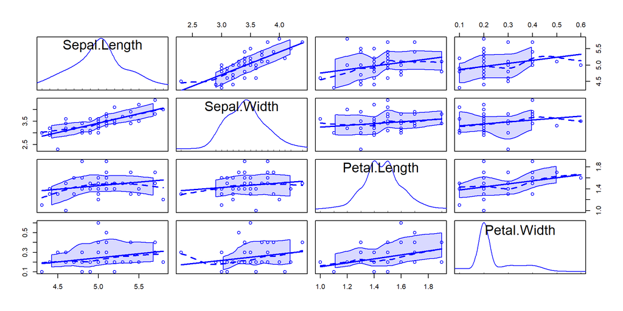

### The Sample Covariane Matrix of Iris Setosa

```r
sample.cov=cov(setosa)
round(sample.cov,2)
```

```
             Sepal.Length Sepal.Width Petal.Length Petal.Width
Sepal.Length         0.12        0.10         0.02        0.01
Sepal.Width          0.10        0.14         0.01        0.01
Petal.Length         0.02        0.01         0.03        0.01
Petal.Width          0.01        0.01         0.01        0.01
```

### The Sample Correlation Matrix of Iris Setosa

```r
sample.corr=cor(setosa)
corrplot(sample.corr)
```

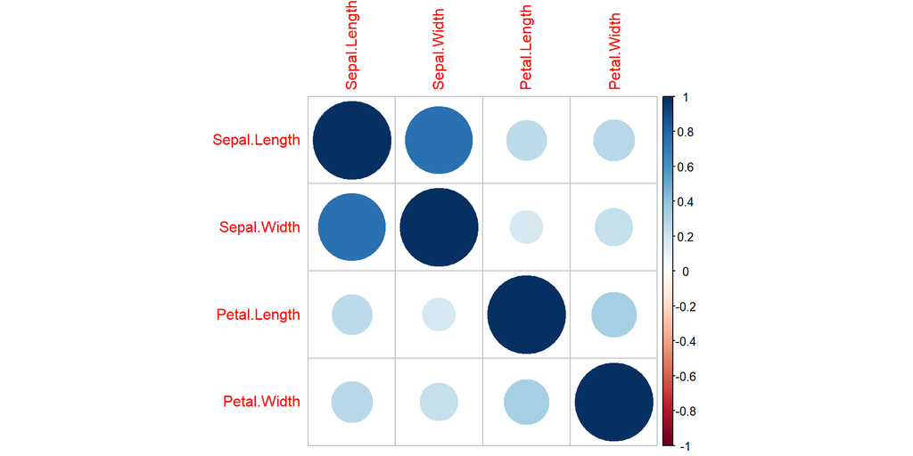

### The Sample Correlation Matrix of Iris Setosa

```r
corrplot(sample.corr, method="number")
```

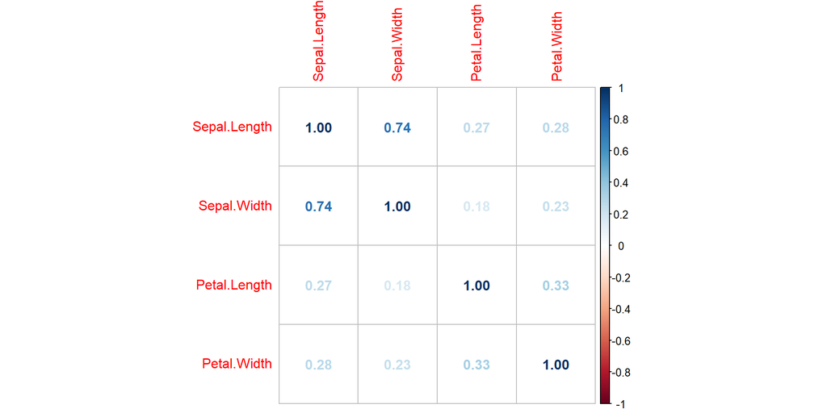

### The Sample Correlation Matrix of Iris Setosa

```r
corrplot(sample.corr, method="ellipse")
```

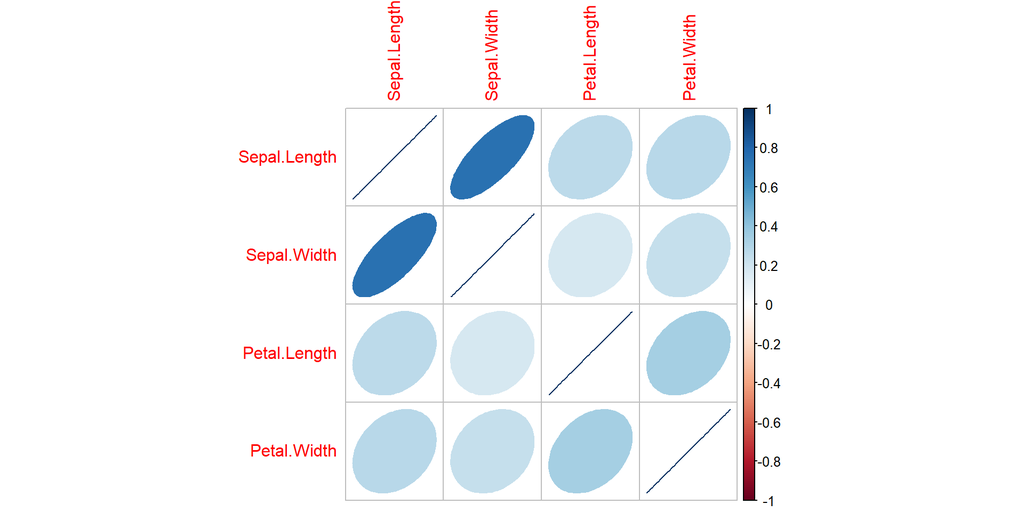

### Sample Covariate Matrix as a Quadratic Form

$$\begin{aligned}
(n-1)S &= \sum (X_i- \bar X) (X_i- \bar X)^T\\
&=
\begin{pmatrix}X_1 - \bar X & \cdots X_n -\bar X\end{pmatrix}
\begin{pmatrix}(X_1 - \bar X)^T \\ \vdots \\(X_n - \bar X)^T\end{pmatrix}
\end{aligned}$$

Note that
$$\begin{pmatrix}(X_1 - \bar X)^T \\ \vdots \\(X_n - \bar X)^T\end{pmatrix}= \begin{pmatrix}X_1 - \bar X \\ \vdots \\ X_n - \bar X\end{pmatrix}^T=\mathbf C\mathbf X$$
where $\mathbf C$ is the centering matrix defined in assignment 1, i.e., $\mathbf C = \mathbf I_n - \frac{1}{n} \mathbf 1 \mathbf 1^T$. In addition, it can be verified that $\mathbf C^T\mathbf C=\mathbf C$.

Therefore,
$$(n-1)S=(C\mathbf X)^T C\mathbf X= \mathbf X^T C \mathbf X$$

# Linear Combinations

## Definition

- Let $\mathbf{X}$ be a $p$-dimensional random vector with mean vector $\boldsymbol{\mu}$ and covariance matrix $\boldsymbol{\Sigma}$.
- Consider a linear combination of the form:
  $$Y = \mathbf{a}^T\mathbf{X}$$

  where $\mathbf{a}$ is a $p$-dimensional constant vector.
- E.g., $\mathbf X = (X_1, X_2, X_3)^T$, $a=(1/3, 1/3, 1/3)^T$. Then
  $$Y=a^TX=\frac{1}{3}(X_1 + X_2 + X_3)$$

## Mean

### Mean of $Y=a^TX$

- The mean of $Y$ can be expressed as:
  $$\begin{aligned}
  E(Y) &= E(\mathbf{a}^T\mathbf{X}) \\
  &= \mathbf{a}^T E(\mathbf{X}) \\
  &= \mathbf{a}^T \boldsymbol{\mu}
  \end{aligned}$$
- Intuitively, the mean of $Y$ is a weighted average of the components of $\mathbf{X}$, with weights given by the corresponding components of $\mathbf{a}$.

## Variance

### Variance of $Y$

- The variance of $Y$ can be expressed as:
  $$\begin{aligned}
  \text{Var}(Y) &= \text{Var}(\mathbf{a}^T\mathbf{X}) \\
  &= E[(\mathbf{a}^T\mathbf{X}-\mathbf{a}^T\boldsymbol\mu)^2]\\
  &=E[(\mathbf{a}^T\mathbf{X}-\mathbf{a}^T\boldsymbol\mu)(\mathbf{a}^T\mathbf{X}-\mathbf{a}^T\boldsymbol\mu)^T]\\
  &=E[\mathbf{a}^T(\mathbf{X}-\boldsymbol\mu)(\mathbf{X}-\boldsymbol\mu)^T\mathbf a]\\
  &= \mathbf{a}^T \boldsymbol{\Sigma} \mathbf{a}
  \end{aligned}$$

### Variance of $Y$ and Quadratic Forms

- The variance of $Y$ depends on the covariance structure of $\mathbf{X}$, as well as the weights given by $\mathbf{a}$.
- We call forms like $\mathbf a^T \boldsymbol \Sigma \mathbf a$ as quadratic forms.
- Note, we can also write the variance of $Y$ as:

$$\begin{aligned}
\mathbf a^T \boldsymbol \Sigma a &&\\
=& \sum_i\sum_j \sigma_{ij} a_i a_j&\\
=& \sigma_{11}a_1^2 + \sigma_{12}a_1 a_2 + \cdots + \sigma_{1p}a_1 a_p + \sigma_{21}a_2 a_1 + \cdots + \sigma_{p1}a_p a_1 + \cdots&\\
=& \sigma_{11}a_1^2 + \sigma_{22}a_2^2 + \cdots + \sigma_{pp}a_p^2 + 2(\sigma_{12}a_1 a_2+ \sigma_{13}a_1 a_3 + \cdots + \sigma_{p-1,p}a_{p-1} a_p)&\\
\end{aligned}$$

## Quadratic Forms

- A quadratic form is a polynomial of degree 2 in the components of a vector, and it can be expressed as:
  $$Q(\mathbf{X}) = \mathbf{X}^T \mathbf{A} \mathbf{X}$$
  where $\mathbf{A}$ is a symmetric matrix.
- We will discuss distributions of certain quadratics forms later.

## Example

### Linear Combinations of Iris Setosa Features

- Recall that for the iris setosa, $\mathbf X$ is $50\times 4$.
- Consider a linear combination of the features $Y= \mathbf Xb$, where

$$b=\begin{pmatrix}
1/4 \\ 1/4 \\ 1/4 \\ 1/4
\end{pmatrix}$$

- $Yb$ is a $50\times 1$ vector, with the $i$th row be the average of the four features of the $i$th iris setosa flower. To see this

### Linear Combinations of Iris Setosa Features

$$\begin{aligned}
Y&=\mathbf Xb=
\begin{pmatrix} X_1^T \\ \vdots \\ X_n^T \end{pmatrix} b
=
\begin{pmatrix} X_1^Tb \\ \vdots \\ X_n^Tb \end{pmatrix}
=\begin{pmatrix} \frac{x_{11} +x_{12} + x_{13} + x_{14}}{4} \\
\vdots \\
\frac{x_{n1} +x_{n2} + x_{n3} + x_{n4}}{4} \end{pmatrix}
\end{aligned}$$

### Linear Combinations of Iris Setosa Features: sample mean

```r
b=matrix(1/4, 4, 1)
Y=setosa%*%b
#sample mean of Y: the following two results are the same
mean(Y)
```

```
[1] 2.5355
```

```r
t(b)%*%sample.meanvec
```

```
       mean
[1,] 2.5355
```

### Linear Combinations of Iris Setosa Features: sample variance

```r
#sample variance of Y: the following two results are the same
var(Y)
```

```
           [,1]
[1,] 0.03844617
```

```r
t(b)%*%cov(setosa)%*%b
```

```
           [,1]
[1,] 0.03844617
```